# DV_FinalProject

## DV_FinalProject

#### Group member: Anna Mengjie Yu (my3852), Duy Vu (dhv242), Syed Naqvi (san724)

With the advent of next generation sequencing, the sequencing cost per genome is decreasing significantly. Genome size, gene content and gene order has been useful in studying species evolution and ecological adaptation. Good data visualization tools will help community better understand the evolution story underneath the data.

In this project, we visualized genomic data from 3 different data sources.

In the first part, we visualized the status of current genome sequencing project and forecast the near future (5 years) in Tableau. We also visualized the cost of genome sequencing in the past decade in Tableau. The workbooks in named NumOfGenomeSequenced.twb. and GenomeCost.twb, respectively.

In the second part, we visualized the animal genome size in Tableau, the data is downloaded from Animal Genome Size Database. And the workbooks are named GenomeSize.twb and Union.twb.

In the last part, we visualized diatom plastid genome data in R. The tables contain plastid genome gene content, gene length and gene order, and they are accessible from Supporting Information in Yu's publicaiton. [http://journals.plos.org/plosone/article?id=10.1371/journal.pone.0107854]

Data storage account information: USER='C##cs329e_my3852', PASS='orcl_my3852'

Load packages

```r
source("../01 Data/loadPackage.R", echo = TRUE)
```

```
##
## > require("ggplot2")
```

```
##
## > require("gplots")
```

```
##
## > require("grid")
```

```
##
## > require("RCurl")
```

```
##
## > require("reshape2")
```

```
##
## > require("tidyr")
```

```
##
## > require("dplyr")
```

```
##
## > require("jsonlite")
```

**Data Visualization Part 1**

**Part 1 Data Source:**

[figure not shown]

Method:

1. Year to Columns
2. Drag Eukaryotes to Rows.
3. Drag Prokaryotes and Viruses to the left Y axis
4. Drag MeasureNames to Color
5. Create a new dashboard, drag this sheet to dashboard, and export it as image.

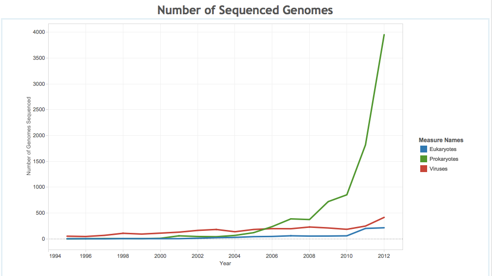

From this graph, we can see the increasing trend of sequenced Eukaryotes, Prokaryotes and Viruses genomes.

The number of sequenced genomes in Prokaryotes increased more sharply from 2010 to 2012, compared to Eukaryotes and Viruses.

**Figure: Forecast of Number of Sequenced Genomes in next 5 Years**

Method:

- Calculated field

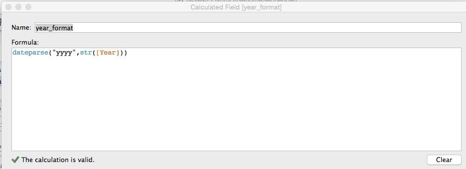

1. Create a calculated field named year_format. We need to convert the Date format since Tableau forecast only accepts data string format for forecast.
2. Drag year_format to Columns
3. Drag Eukaryotes to Rows
4. Drag Prokaryotes and Viruses to the Y axis.
5. Click on Analysis, on the drag down menu click on forecast, click on show forecast.
6. Click on forecast options, choose exactly 5 year forecast.
7. Right click on the graph, click on show trendline.
8. Click on the Edit trendline option, choose model type to Exponential.

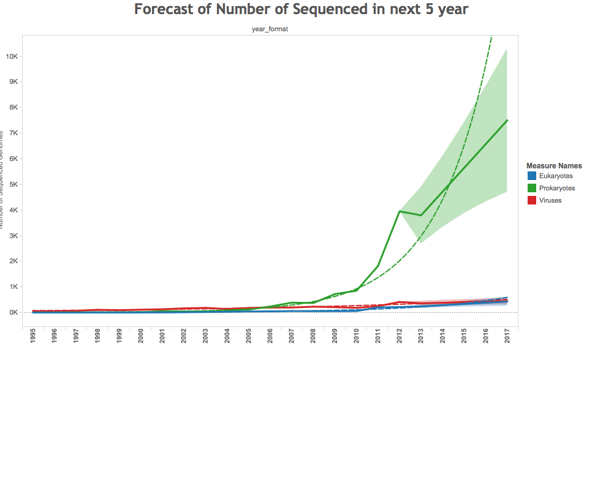

**Figure: Sequencing Cost in past 10 years**

Method:

1. Drag Dates to Columns.
2. Drag Cost per genome to Rows.
3. Drag Cost Per Mb to Rows.
4. Drag Cost per genome to label.
5. Drag Cost Per Mb to label.
6. Create a new dashboard
7. Drag the Genome Sequencing Cost sheet to dashboard, and export it as image.

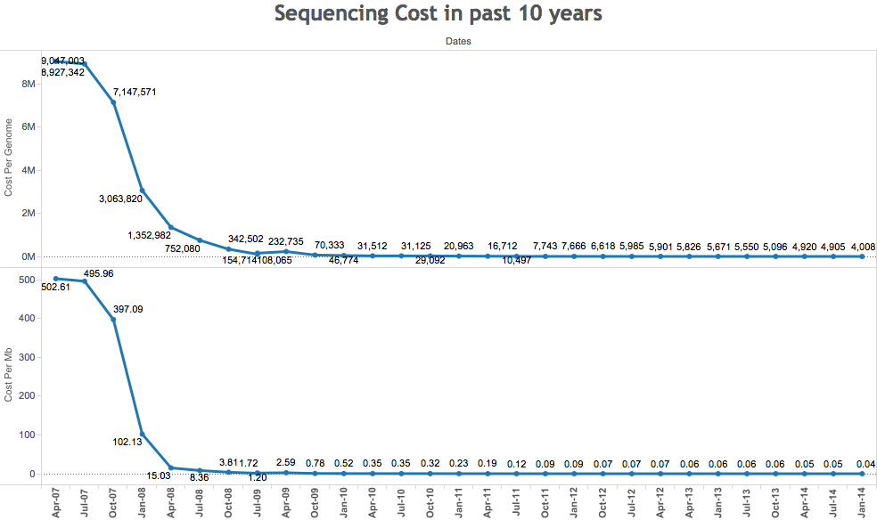

From this graph, we can see that the decreasing trend of genome sequencing cost (per Million basepair and per human-sized genome).

We observed a sharp decrease in genome sequencing cost from 2007 to 2008. After 2008, the genome sequencing cost is still decreasing, but in a much slower rate.

**Figure: Trend of Genome Sequencing Cost**

Method:

1. Besides above methods, we right click on show trend line.
2. Click on the Edit trendline option, choose model type to Exponential.
3. Edit trendline color, change it to red.

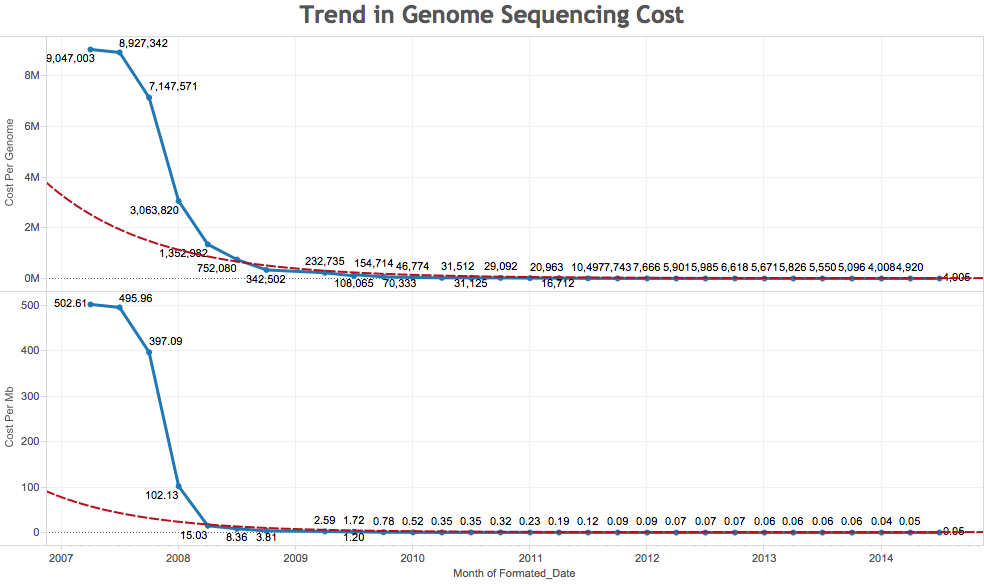

From this genome sequencing cost trendline, we can see the slowly decreasing or stable trend in genome sequencing cost in the near future.

**Data Visualization Part 2**

**Part 2 Data Source:**

[figure not shown]

**Figure: A Snapshot of Animal Genome Data**

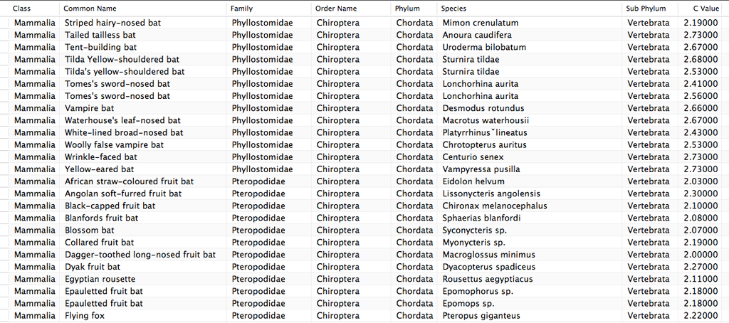

**Figure: C Value in Different Animal Groups**

Method:

1. Use the barrel button to load all 5 tables from oracle database.
2. Drag C Val to Rows for each table, in Show Me choose box-and-whisker plot
3. Create a new dashboard
4. Drag each C value box-and-whisker plot to dashboard, and add a name to dashboard

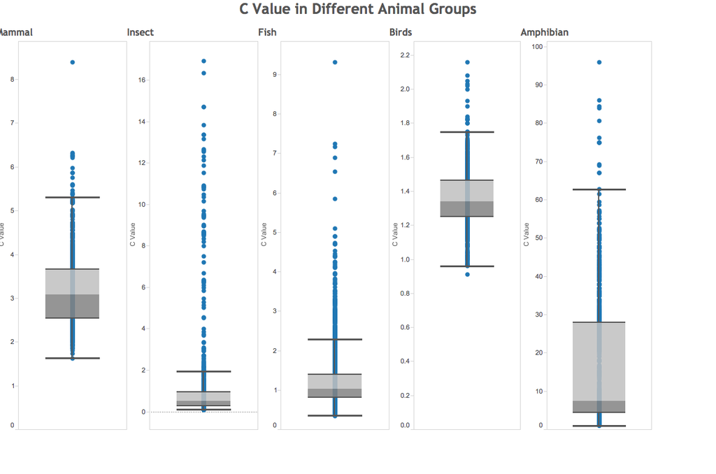

From this figure, we can see that C value differs a lot among all five animal groups.

The Amphibian group shows the widest distribution of C values.

The Bird group shows the narrowest distribution of C values.

**Figure: Median C Value and Number of Records in Mammal Orders**

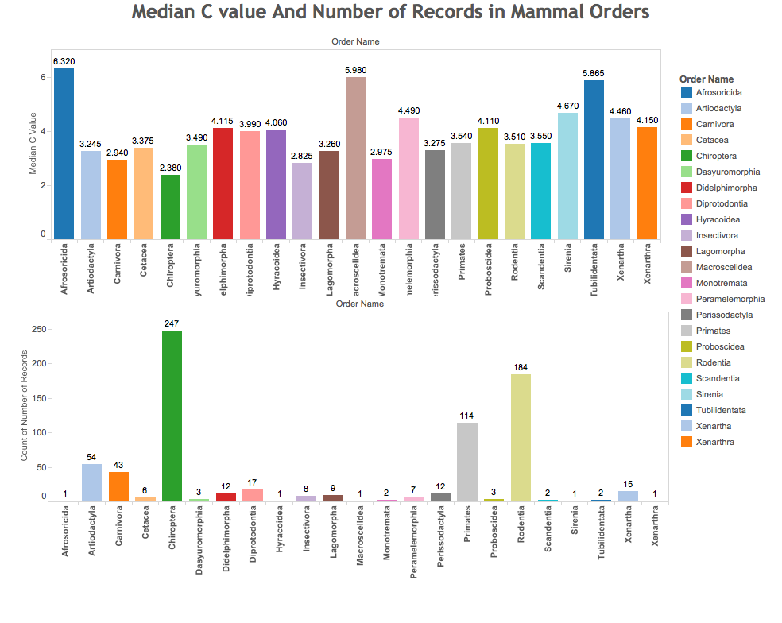

In this figure we can see the Afrosoricida order in Mammal (hedgehog and moles) has the largest genome size.

The Chiroptera order (bats) has the smallest genome size.

The closest relative to humans (primates) has medium genome size among the mammals.

**Figure: Median C Value in Different Bird Orders**

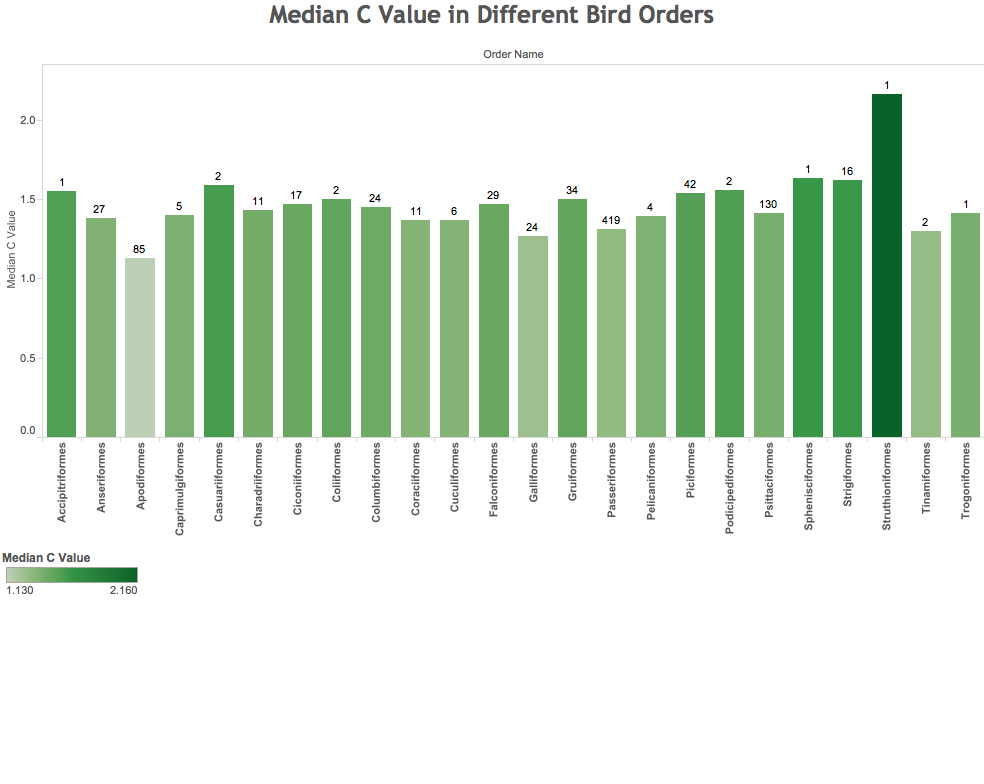

In this figure, we show the genome size distribution in different orders in birds.

The interger numbers on top of each bar indicate the number of organisms sequenced in each bird order.

From this figure, we can see Struthioniformes (Ostrich) has the largest genome size (as indicated by dark green), and Apodiformes (hummingbirds) has the smallest genome size (as indicated by pale green).

**Figure: Median C Value in Different Amphibian Species**

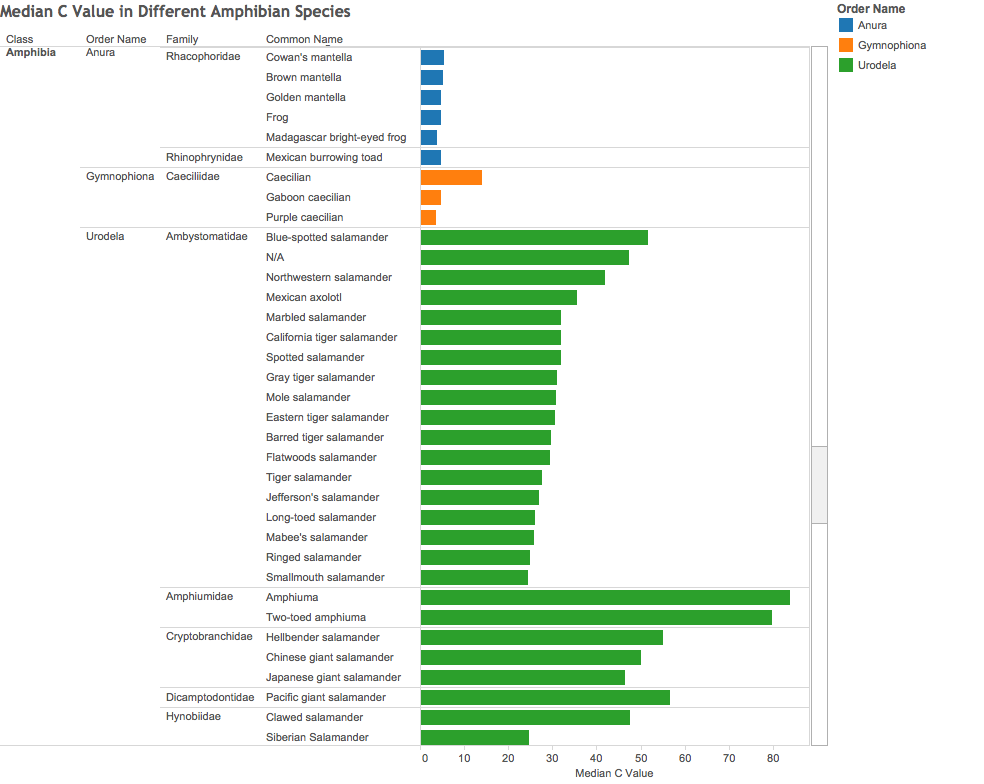

This figure shows the distribution genome size (C Value)in Amphibian groups.

The bars are colored by different orders.

We can see Amphiumidae (salamander) has the largest genome size in sequenced Amphibians (green).

And Caeciliidae (frog) has the smallest genome size in sequenced Amphibians (orange)

**Figure: Snapshot of using Table SQL option to Union Tables**

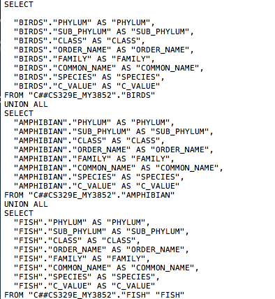

This snippet of code shows how we union the 5 animal genome size tables together.

**Figure: Distribution of C Value in Five Animal Groups**

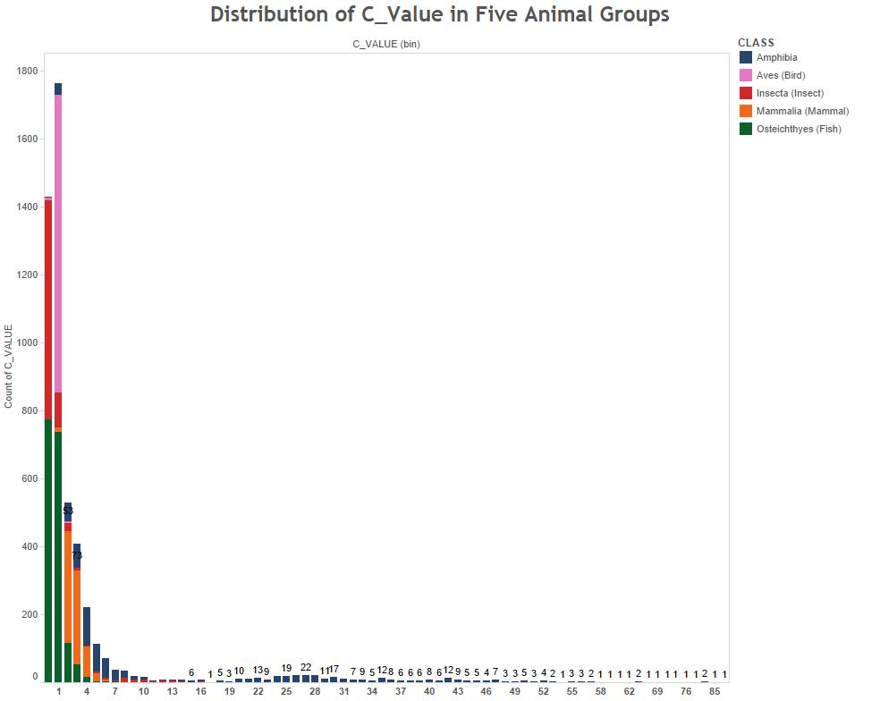

This graph shows the distribution of C values in all 5 animal groups.

We can see Amphibian has the largest V value distribution, as indicated in blue color.

Most C Values are within 0-4.

**Table: Nth largest C Value in each class**

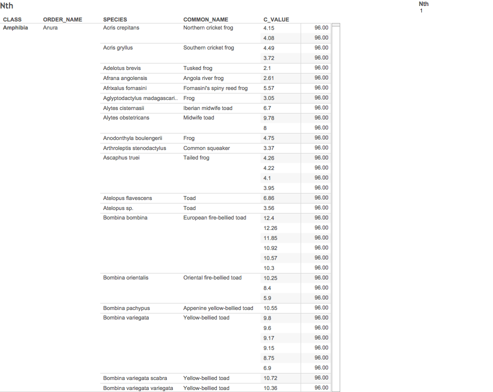

We created a crosstab to calculate the Nth rank of genome size in each Class.

This table shows the 1st ranked genome size (C value) in each class.

**Data Visualization Part 3**

**Part 3 Data Source:**

[figure not shown]

Load packages

```r
source("../01 Data/loadPackage.R", echo = TRUE)
```

```
##
## > require("ggplot2")
##
## > require("gplots")
##
## > require("grid")
##
## > require("RCurl")
##
## > require("reshape2")
##
## > require("tidyr")
##
## > require("dplyr")
##
## > require("jsonlite")
```

First, we displayed a few lines of the dataset stored in oracle database. The table includes Name(gene name), MINIMUM (gene start position), MAXIMUM(gene end position), LENGTH(gene length), DIRECTION(sense and anti-sense strand).

**Table: Plastid Genome Data**

```r
source("../01 Data/Diatoms.R", echo = TRUE)
```

```
##
## > cyclotella <- data.frame(eval(parse(text = substring(getURL(URLencode("http://129.152.144.84:5001/rest/native/?query=\"select * from cyclotella\""), .... [TRUNCATED]
##
## > cyclotella %>% tbl_df
## Source: local data frame [180 x 5]
##
##              NAME MINIMUM MAXIMUM LENGTH DIRECTION
## 1       psaA gene     103   2,361  2,259   forward
## 2       psaB gene   2,478   4,679  2,202   forward
## 3       petF gene   4,912   5,244    333   reverse
## 4      rpl20 gene   5,425   5,844    420   reverse
## 5      rpl35 gene   5,854   6,048    195   reverse
## 6      ycf42 gene   6,055   6,690    636   reverse
## 7       psaE gene   6,792   6,989    198   reverse
## 8  trnR(ucu) gene   7,154   7,226     73   reverse
## 9  trnV(uac) gene   7,237   7,308     72   reverse
## 10      psbH gene   7,575   7,775    201   reverse
## ..            ...     ...     ...    ...       ...
##
## > cera <- data.frame(fromJSON(getURL(URLencode("129.152.144.84:5001/rest/native/?query=\"select * from cerataulina\""),
## +     httpheader = c(DB = "jd ..." ... [TRUNCATED]
##
## > cera %>% tbl_df
## Source: local data frame [169 x 5]
##
##             NAME MINIMUM MAXIMUM LENGTH DIRECTION
## 1      psaA gene     362   2,620  2,259   forward
## 2      psaB gene   2,712   4,913  2,202   forward
## 3  trnD-GUC gene   5,037   5,110     74   reverse
## 4  trnS-GCU gene   5,175   5,260     86   reverse
## 5  trnI-CAU gene   5,298   5,369     72   reverse
## 6     ycf33 gene   5,546   5,740    195   forward
## 7  trnY-GUA gene   7,698   7,780     83   reverse
## 8  trnV-UAC gene   8,306   8,371     66   forward
## 9  trnR-UCU gene   8,383   8,455     73   forward
## 10     trnT(ugu)   8,768   8,839     72   reverse
## ..           ...     ...     ...    ...       ...
##
## > chaeto <- data.frame(fromJSON(getURL(URLencode("129.152.144.84:5001/rest/native/?query=\"select * from chaetoceros\""),
## +     httpheader = c(DB = " ..." ... [TRUNCATED]
```

[output cut: 39 more lines]

```
## > weiss %>% tbl_df
## Source: local data frame [180 x 5]
##
##              NAME MINIMUM MAXIMUM LENGTH DIRECTION
## 1      rpl32 gene 120,353 120,517    165   reverse
## 2       psbY gene 120,762 120,872    111   reverse
## 3       rrn5 rRNA 121,057 121,182    126   reverse
## 4             rns 121,332 124,090  2,759   reverse
## 5   trnA-UGC gene 124,179 124,251     73   reverse
## 6   trnI-GAU gene 124,254 124,327     74   reverse
## 7             rnl 124,384 125,860  1,477   reverse
## 8      ycf89 gene 126,149 127,111    963   reverse
## 9  trnP(ugg) gene 127,458 127,531     74   forward
## 10      psaA gene     142   2,400  2,259   forward
## ..            ...     ...     ...    ...       ...
```

**Data Wrangling**

1.For each original table, create new column gene_family by extracting the first three charaters from gene NAME, and further group by gene family.

```r
source("../02 Data Wrangling/Diatoms_geneFamily.R", echo = TRUE)
```

```
##
## > cyc_gf <- cyclotella %>% mutate(gene_family = substr(NAME,
## +     1, 3)) %>% group_by(gene_family)
##
## > cyc_gf %>% tbl_df
## Source: local data frame [180 x 6]
##
##              NAME MINIMUM MAXIMUM LENGTH DIRECTION gene_family
## 1       psaA gene     103   2,361  2,259   forward         psa
## 2       psaB gene   2,478   4,679  2,202   forward         psa
## 3       petF gene   4,912   5,244    333   reverse         pet
## 4      rpl20 gene   5,425   5,844    420   reverse         rpl
## 5      rpl35 gene   5,854   6,048    195   reverse         rpl
## 6      ycf42 gene   6,055   6,690    636   reverse         ycf
## 7       psaE gene   6,792   6,989    198   reverse         psa
## 8  trnR(ucu) gene   7,154   7,226     73   reverse         trn
## 9  trnV(uac) gene   7,237   7,308     72   reverse         trn
## 10      psbH gene   7,575   7,775    201   reverse         psb
## ..            ...     ...     ...    ...       ...         ...
##
## > weiss_gf <- weiss %>% mutate(gene_family = substr(NAME,
## +     1, 3)) %>% group_by(gene_family)
##
## > weiss_gf %>% tbl_df
## Source: local data frame [180 x 6]
##
##              NAME MINIMUM MAXIMUM LENGTH DIRECTION gene_family
## 1      rpl32 gene 120,353 120,517    165   reverse         rpl
## 2       psbY gene 120,762 120,872    111   reverse         psb
## 3       rrn5 rRNA 121,057 121,182    126   reverse         rrn
## 4             rns 121,332 124,090  2,759   reverse         rns
## 5   trnA-UGC gene 124,179 124,251     73   reverse         trn
## 6   trnI-GAU gene 124,254 124,327     74   reverse         trn
## 7             rnl 124,384 125,860  1,477   reverse         rnl
## 8      ycf89 gene 126,149 127,111    963   reverse         ycf
## 9  trnP(ugg) gene 127,458 127,531     74   forward         trn
## 10      psaA gene     142   2,400  2,259   forward         psa
## ..            ...     ...     ...    ...       ...         ...
##
## > cera_gf <- cera %>% mutate(gene_family = substr(NAME,
```

[output cut: 40 more lines]

```
## > ocean_gf %>% tbl_df
## Source: local data frame [185 x 6]
##
##           NAME START_POS END_POS LENGTH DIRECTION gene_family
## 1     psaA CDS       122    2380   2259   forward         psa
## 2     psaB CDS      2484    4685   2202   forward         psa
## 3    trnV tRNA      5389    5460     72   forward         trn
## 4  trnR-2 tRNA      5480    5552     73   forward         trn
## 5   orf127 CDS      6165    6587    423   reverse         orf
## 6    rpl19 CDS      7142    7504    363   reverse         rpl
## 7  trnM-2 tRNA      7591    7675     85   reverse         trn
## 8   ssra tmRNA      7680    8013    334   reverse         ssr
## 9  trnR-1 tRNA      8072    8144     73   reverse         trn
## 10    atpA CDS      9008   10519   1512   reverse         atp
## ..         ...       ...     ...    ...       ...         ...
```

1. We calculated the average gene length in each gene family using T.oceanica data set.

   ```r
   source("../02 Data Wrangling/Ocean_gf_len.R", echo = TRUE)
   ```

   ```
   ##
   ## > ocean_gf_len <- ocean_gf %>% group_by(gene_family) %>%
   ## +     summarise(avg_gene_length = mean(LENGTH))
   ##
   ## > ocean_gf_len %>% tbl_df
   ## Source: local data frame [29 x 2]
   ##
   ##    gene_family avg_gene_length
   ## 1          atp           736.5
   ## 2          cbb           864.0
   ## 3          ccs          1122.0
   ## 4          chl          1059.0
   ## 5          clp          2799.0
   ## 6          dna          1596.0
   ## 7          ffs           100.0
   ## 8          flr            75.0
   ## 9          fts          1929.0
   ## 10         gro          1593.0
   ## ..         ...             ...
   ```

**Data Visualization**

```r
source("../03 Visualizations/Ocean_gf_len.R", echo = TRUE)
```

```
##
## > ggplot(ocean_gf_len, aes(y = avg_gene_length, x = gene_family,
## +     group = 1)) + stat_smooth(se = TRUE, size = 2, method = loess) +
## +     geom_p .... [TRUNCATED]
```

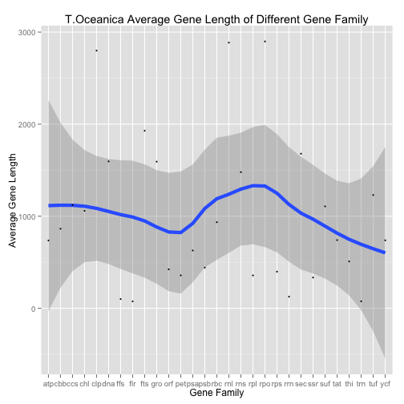

From this graph, we can see the average gene length in different gene families from the blue line. The shaded area indicates 95% confidence interval.

```r
source("../03 Visualizations/Ocean_gf_cnt.R", echo = TRUE)
```

```
##
## > ocean_g <- ggplot(data = ocean_gf, mapping = aes(x = gene_family)) +
## +     layer(geom = "bar", mapping = aes(fill = DIRECTION)) + labs(title = "Tha ..." ... [TRUNCATED]
##
## > ocean_g
```

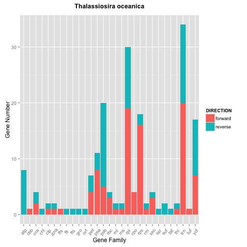

In this graph, the x axis represents different gene families, the y axis represents number of genes. From the legend, we can see the red color indicates genes in forward direction, and blue indicates genes in reverse direction.

From this graph, we can see the trn gene family has the largest numbr of genes. And some gene family only have genes in one direction.

```r
source("../03 Visualizations/FiveDiatoms.R", echo = TRUE)
```

```
##
## > l_gf <- list()
##
## > ocean_g <- ggplot(data = ocean_gf, mapping = aes(x = gene_family)) +
## +     layer(geom = "bar", mapping = aes(fill = DIRECTION)) + labs(title = "Tha ..." ... [TRUNCATED]
##
## > ocean_g
```

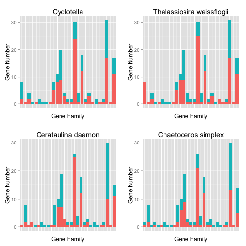

```
##
## > l_gf[[1]] <- ggplot(data = cyc_gf, mapping = aes(x = gene_family)) +
## +     layer(geom = "bar", mapping = aes(fill = DIRECTION)) + labs(title = "Cyc ..." ... [TRUNCATED]
##
## > l_gf[[2]] <- ggplot(data = weiss_gf, mapping = aes(x = gene_family)) +
## +     layer(geom = "bar", mapping = aes(fill = DIRECTION)) + labs(title = "T ..." ... [TRUNCATED]
##
## > l_gf[[3]] <- ggplot(data = cera_gf, mapping = aes(x = gene_family)) +
## +     layer(geom = "bar", mapping = aes(fill = DIRECTION)) + labs(title = "Ce ..." ... [TRUNCATED]
##
## > l_gf[[4]] <- ggplot(data = chaeto_gf, mapping = aes(x = gene_family)) +
## +     layer(geom = "bar", mapping = aes(fill = DIRECTION)) + labs(title = " ..." ... [TRUNCATED]
##
## > pushViewport(viewport(layout = grid.layout(2, 4)))
##
## > print(l_gf[[1]], vp = viewport(layout.pos.row = 1,
## +     layout.pos.col = 1:2))
##
## > print(l_gf[[2]], vp = viewport(layout.pos.row = 1,
## +     layout.pos.col = 3:4))
##
## > print(l_gf[[3]], vp = viewport(layout.pos.row = 2,
## +     layout.pos.col = 1:2))
##
## > print(l_gf[[4]], vp = viewport(layout.pos.row = 2,
## +     layout.pos.col = 3:4))
```

In this graph, we used the pushViewport to visualize gene number in different gene families for 4 diatom species.

From this graph, we can see that, the number of genes in different direction differ in different species. From the 1st average gene length figure, we can see that each gene family has different average gene length.

The different number of genes, and different gene length, might be a cause contributing to different genome sizes.